# Estimated change in mortality associated with the introduction of vaccine in Brazil

# Results

```r
if (!is.null(names(analysis$sparse_groups[analysis$sparse_groups])) && length(names(analysis$sparse_groups[analysis$sparse_groups])) != 0) {
  print(xtable(data.frame("Sparse Groups" = names(analysis$sparse_groups[analysis$sparse_groups]), check.names = FALSE), align = "cc"), type="html")
}
```

## combine estimates

```r
if (params$crossval) {
  print(xtable(cbind.data.frame(crossval_results$rr_mean_stack_intervals, impact_results$full$rr_mean_intervals, impact_results$time$rr_mean_intervals, impact_results$time_no_offset$rr_mean_intervals, impact_results$its$rr_mean_intervals, impact_results$pca$rr_mean_intervals), align = "ccccccc"), type="html")
} else {
  print(xtable(cbind.data.frame(impact_results$best$rr_mean_intervals, impact_results$full$rr_mean_intervals, impact_results$time$rr_mean_intervals, impact_results$time_no_offset$rr_mean_intervals, impact_results$its$rr_mean_intervals, impact_results$pca$rr_mean_intervals), align = "ccccccc"), type="html")
}
```

|  | Estimate (95% CI) | Synthetic controls Estimate (95% CI) | Time trend Estimate (95% CI) | Time trend (no offset) Estimate (95% CI) | Classic ITS (95% CI) | STL+PCA Estimate (95% CI) |
| --- | --- | --- | --- | --- | --- | --- |
| 9 | 0.74 (0.67, 0.78) | 0.74 (0.67, 0.78) | 0.73 (0.64, 0.83) | 0.88 (0.76, 0.99) | 0.83 (0.73, 0.94) | 0.83 (0.76, 0.9) |

## Cases averted

How many cases were prevented from the time of vaccine introduction to the last time point in each stratum (+/- 95% CrI)? You can modify the number ‘last.point’ to pull out the cumulative number of cases at any point in the time series

```r
last.point<-dim(impact_results$best$cumsum_prevented)[1]
cum.prevented<-impact_results$best$cumsum_prevented[last.point,,]
print(cum.prevented)
```

```
#>      2.5%       50%     97.5%
#>  75253.57  95884.50 149045.45
```

## Plot of Rate ratios, with size proportional to cross validation weights

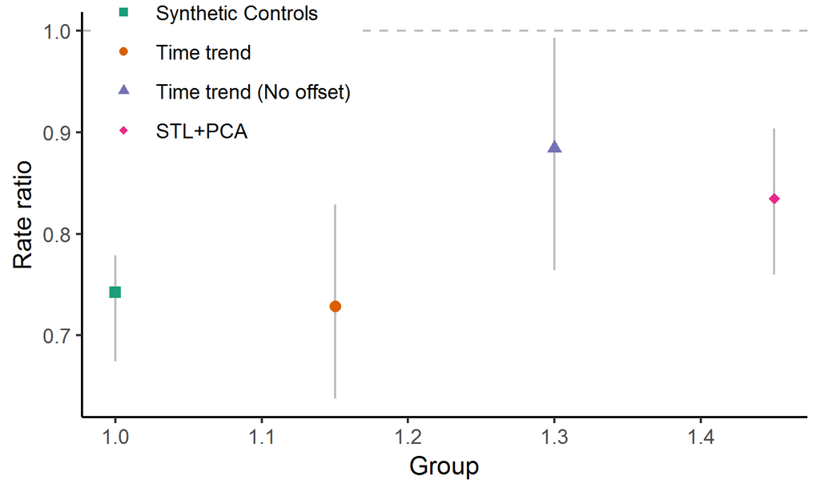

## Number of variables selected in SC analysis

```r
model_size = data.frame(t(analysis$model_size))
print(xtable(setNames(model_size, c("Model Size")), align=rep("c", ncol(model_size) + 1)), type="html")
```

|  | Model Size |
| --- | --- |
| 1 | 2.68 |

## Inclusion Probabilities

```r
print(xtable(incl_probs, align = rep("c", ncol(incl_probs) + 1)), type="html")
```

|  | Group | Greatest Inclusion Variable | Greatest Inclusion Probability | Second Greatest Inclusion Variable | Second Greatest Inclusion Probability | Third Greatest Inclusion Variable | Third Greatest Inclusion Probability |
| --- | --- | --- | --- | --- | --- | --- | --- |
| 1 | 9 | E40_46 | 1.00 | cJ20_J22 | 1.00 | A41 | 0.22 |

## Weight Sensitivity Analysis

```r
if (exists("sensitivity_results")) {
  print(xtable(sensitivity_results$sensitivity_table_intervals, align = rep("c", ncol(sensitivity_results$sensitivity_table_intervals) + 1)), type="html")
}
```

|  | Estimate (95% CI) | Top Control 1 | Inclusion Probability of Control 1 | Control 1 Estimate (95% CI) | Top Control 2 | Inclusion Probability of Control 2 | Control 2 Estimate (95% CI) | Top Control 3 | Inclusion Probability of Control 3 | Control 3 Estimate (95% CI) |
| --- | --- | --- | --- | --- | --- | --- | --- | --- | --- | --- |
| 1 | 0.74 (0.67, 0.78) | cJ20_J22 | 1 | 0.79 (0.73, 0.86) | E40_46 | 1 | 0.86 (0.77, 0.94) | A41 | 0.22 | 0.81 (0.57, 0.98) |

## Plot Observed vs expected monthly time series

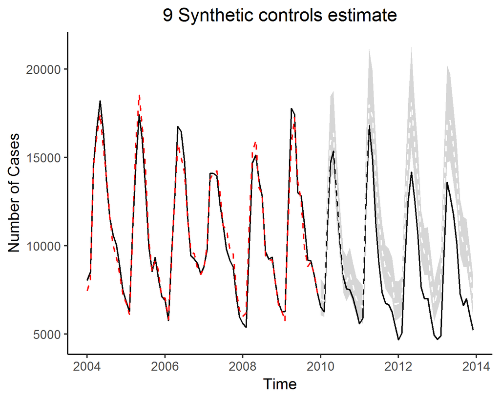

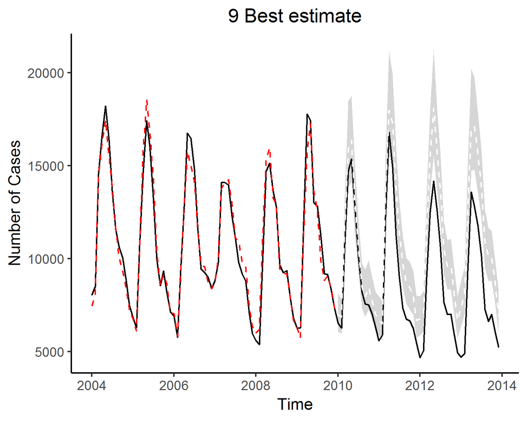

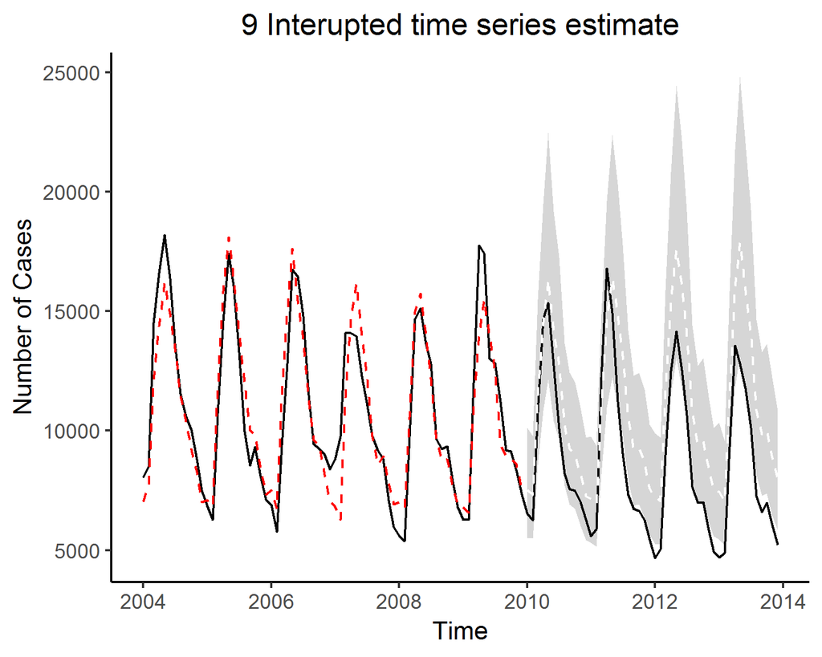

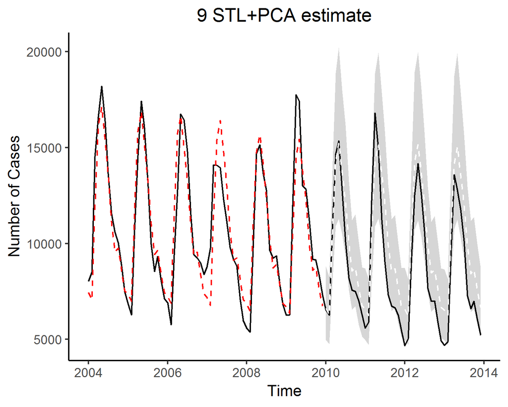

```r
for (group in names(plots$groups)) {
      par(mfrow=c(4,1))
      print(plots$groups[[group]]$pred_full )
      print(plots$groups[[group]]$pred_best )
      print(plots$groups[[group]]$pred_time )
      print(plots$groups[[group]]$pred_pca )
}
```

## Plot Observed vs expected yearly time series

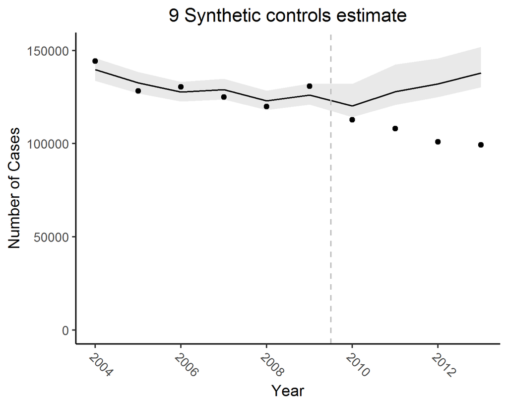

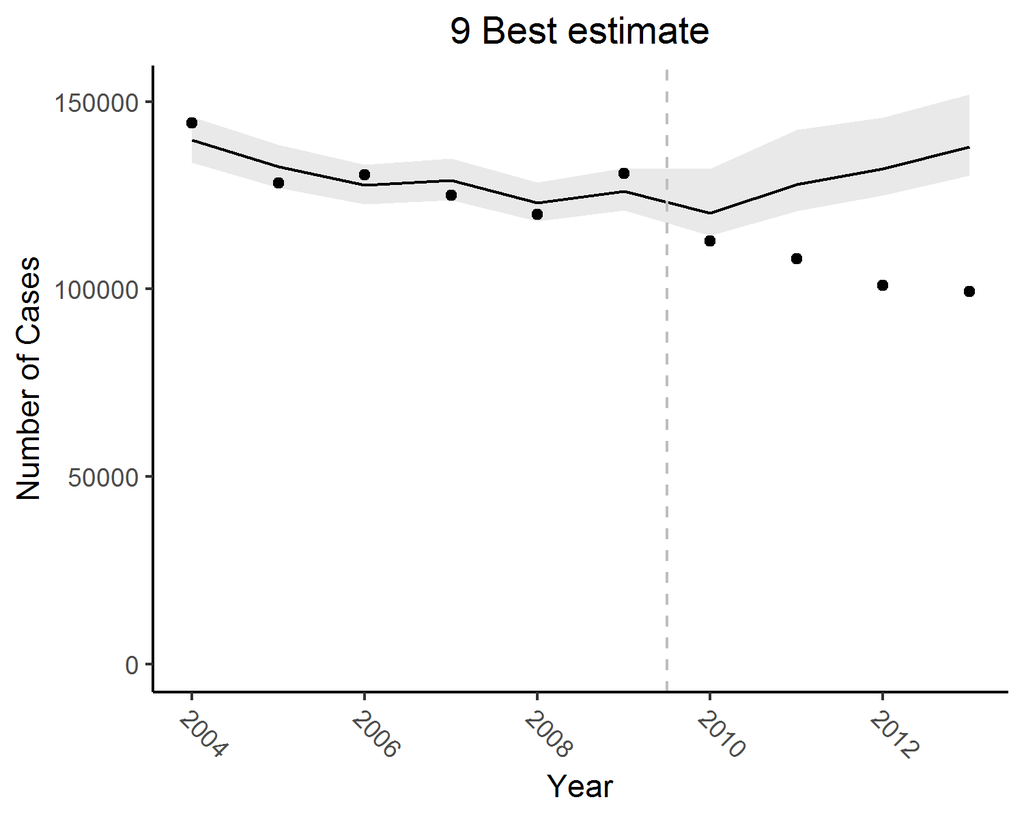

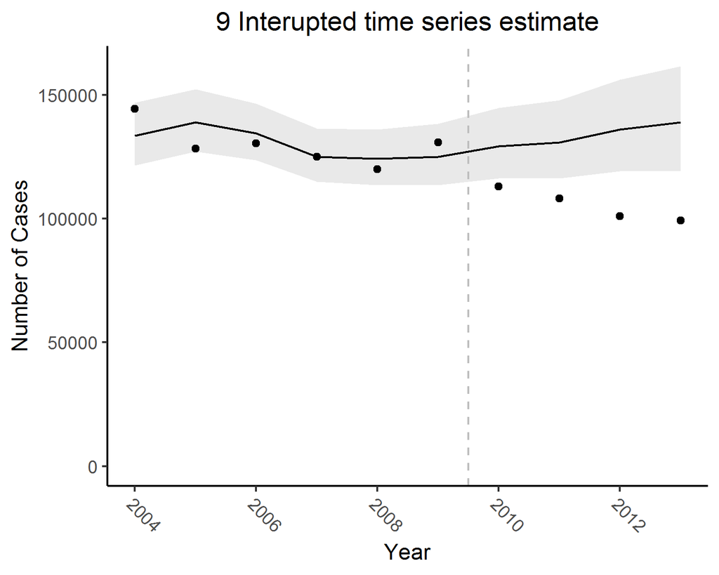

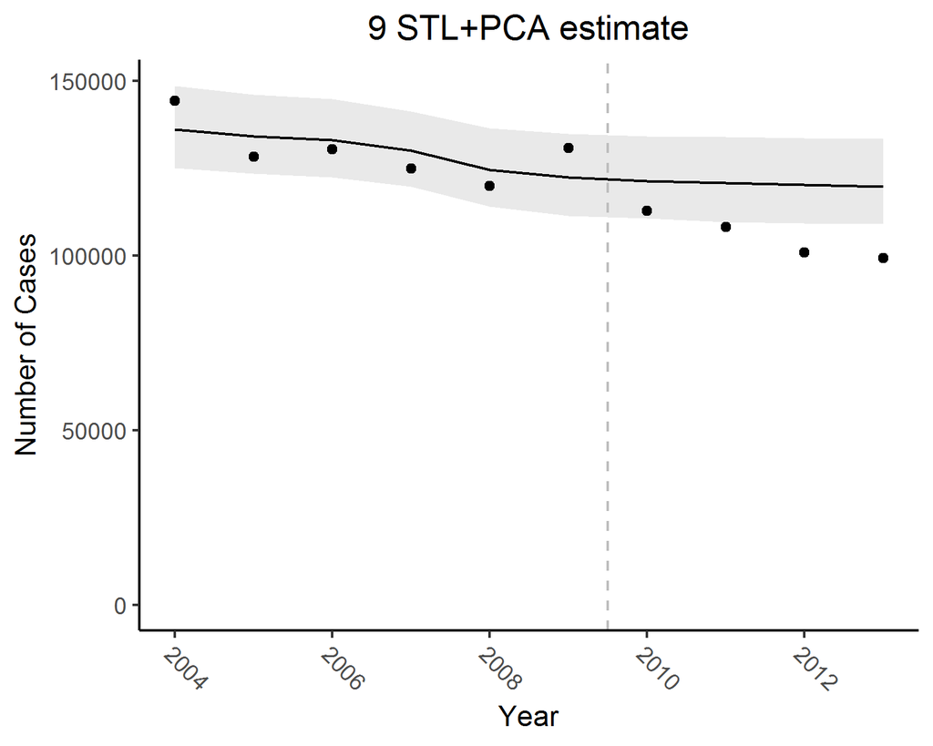

```r
for (group in names(plots$groups)) {
      par(mfrow=c(4,1))
      print(plots$groups[[group]]$pred_full_agg )
      print(plots$groups[[group]]$pred_best_agg )
      print(plots$groups[[group]]$pred_time_agg )
      print(plots$groups[[group]]$pred_pca_agg )
}
```

## Plot cumulative cases prevented

Estimated using the ‘best’ model, between SC and STL+PCA

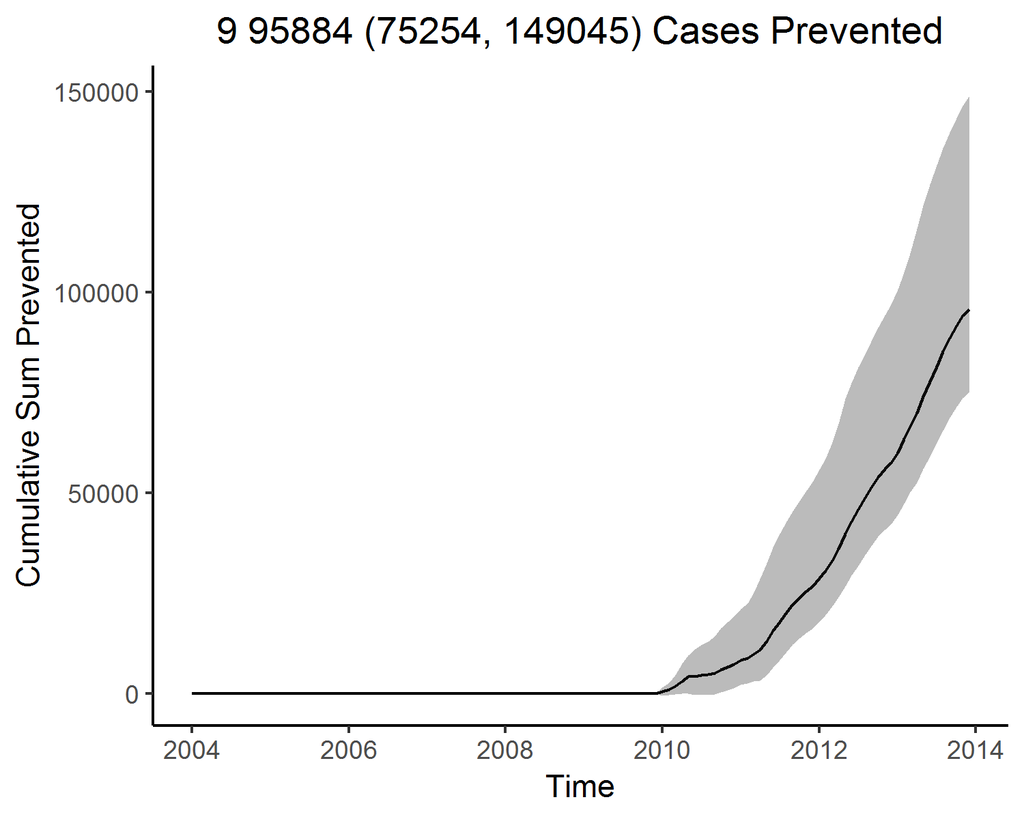

```r
for (group in names(plots$groups)) {
      par(mfrow=c(4,1))
      print(plots$groups[[group]]$cumsum_prevented )
}
```

### Use HDI intervals instead

The package calcuates both an equal-tail 95% credible interval and a 95% highest posterior density interval (HPD or HDI interval). The latter might be more appropriate when the posterior distribution is skewed. The objects with HDI intervals are saved with an appendix of ‘HDI’ so –impact_results$best$pred_quantiles gives the estimate for equal tail intervals while –impact_results$best$pred_quantiles_HDI gives the estimate for the HDI interval –impact_results$best$cumsum_prevented_hdi gives the estimate of cumulative cases prevented using HPI –impact_results$best$ann_pred_HDI gives the annual predicted cases with HDI intervals –impact_results$best$rr_mean_HDI gives the overall rate ratio caclulated with HDI intervals – impact_results$best$log_rr_hdi gives the pointswise log-RR with HDI intervals Here we compare the version calculated with equal-tailed intervals with HPD intervals. In this example they give very similar coverage

```r
impact_results$best$rr_mean
```

```
#>    Lower CI Point Estimate  Upper CI
#> 9 0.6742782      0.7424643 0.7787071
```

```r
impact_results$best$rr_mean_hdi
```

```
#>   Point Estimate     lower     upper
#> 9      0.7424643 0.6796056 0.7830177
```

Compare pointwise coverage of the 95% CrI calculated as HDI or equal-tailed. In this example they are nearly identical

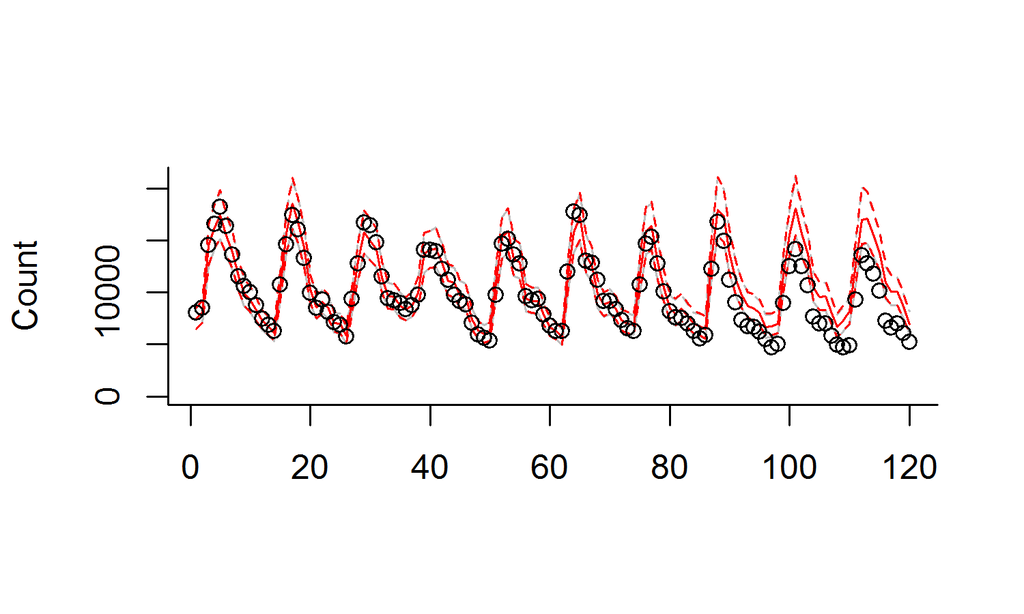

```r
matplot(impact_results$best$pred_quantiles_HDI[,,1], type='l', col='gray', lty=c(2,1,2), bty='l', ylim=c(0, max(impact_results$best$pred_quantiles_HDI[,,1])), ylab='Count')
matplot(impact_results$best$pred_quantiles[,,1], type='l', col='red', lty=c(2,1,2), bty='l', ylim=c(0, max(impact_results$best$pred_quantiles_HDI[,,1])), ylab='Count', add=T)
points(analysis$input_data[, analysis$outcome_name])
```